# Project - Machine Learning

Vijay

April 29, 2017

## Introduction

With the increase in the usage of activity trackers we have a lot of data available with us in regards to fitness and activities. In this paper I am going to look one such huge data generated from the usage of few people. We will look at all the parameters in the dataset, cleanse them, use only the required parameters and build a model based on that to predict the activity based on the measurements. We will then use the same model to predict what the activity on a test dataset.

## Exploring the data

We will load the required library and read the complete dataset into R

```r
library(caret)
library(e1071)
set.seed(1234)
training_initial <- read.csv("pml-training.csv")
```

When looking at the file we can see that there are many columns with missing values. Let us see how many columns have more than 90% of missing values. These predictors with so much missing values will not add any value to the model. Instead it may affect the accuracy of the models. We will remove them from our training dataset

```r
missing_cols <- colnames(training_initial)[(colSums(is.na(training_initial))/nrow(training_initial)) > 0.9]
trainingv1 <- training_initial[ , !(names(training_initial) %in% missing_cols)]
```

Again there are many columns with blank values. We will do the same what we did for the missing values to these blank values.

```r
blank_cols <- colnames(trainingv1)[(colSums(trainingv1 == "")/nrow(trainingv1)) > 0.9]
trainingv2 <- trainingv1[ , !(names(trainingv1) %in% blank_cols)]
table(trainingv2$new_window)
```

```
##
##    no   yes
## 19216   406
```

Now looking at the remining predictors the name and timestamp will not add anything to model for predicting what activity they are performing. Also the new_window columns are having very less variability so we will remove those columns and form our final training dataset using which we can predict our model.

```r
trainingv3 <- trainingv2[, -c(1:7)]
head(trainingv3)
```

```
##   roll_belt pitch_belt yaw_belt total_accel_belt gyros_belt_x gyros_belt_y
## 1      1.41       8.07    -94.4                3         0.00         0.00
## 2      1.41       8.07    -94.4                3         0.02         0.00
## 3      1.42       8.07    -94.4                3         0.00         0.00
## 4      1.48       8.05    -94.4                3         0.02         0.00
## 5      1.48       8.07    -94.4                3         0.02         0.02
## 6      1.45       8.06    -94.4                3         0.02         0.00
##   gyros_belt_z accel_belt_x accel_belt_y accel_belt_z magnet_belt_x
## 1        -0.02          -21            4           22            -3
## 2        -0.02          -22            4           22            -7
## 3        -0.02          -20            5           23            -2
## 4        -0.03          -22            3           21            -6
## 5        -0.02          -21            2           24            -6
## 6        -0.02          -21            4           21             0
##   magnet_belt_y magnet_belt_z roll_arm pitch_arm yaw_arm total_accel_arm
```

[output cut: 69 more lines]

```r
training <- trainingv3
```

## Model Selection

Now we have got all the necessary and only required data for our analysis we will split the model into a training and validation dataset. Since we have close to 20K observations we can go for a 50:50 model for training and validation.

```r
intrain <- createDataPartition(y=training$classe,
                               p=0.5, list=FALSE)
newtrainDF <- training[intrain,]
validDF <- training[-intrain,]
newvalidDF <- validDF[,!(names(validDF) %in% "classe")]
```

Now we get into what algorithm we can use to build our model. Since the output is a factor variable it and the predictors are all numeric variable it will be best to use a tree type of model. The decision tree may be used for simple models with less predictors. Random forest will be the best suited algorithm for this kind of data that we want to predict. Let us build a model and see how it works on our validation data

```r
RFfit <- train(classe ~ ., method = "rf", data = newtrainDF)
testmodel <- predict(RFfit,newvalidDF)
confusionMatrix(testmodel,validDF$classe)
```

```
## Confusion Matrix and Statistics
##
##           Reference
## Prediction    A    B    C    D    E
##          A 2784   23    0    0    0
##          B    4 1864    9    0    0
##          C    1   11 1697   17    7
##          D    0    0    5 1588    6
##          E    1    0    0    3 1790
##
## Overall Statistics
##
##                Accuracy : 0.9911
##                  95% CI : (0.9891, 0.9929)
##     No Information Rate : 0.2844
##     P-Value [Acc > NIR] : < 2.2e-16
##
##                   Kappa : 0.9888
##  Mcnemar's Test P-Value : NA
##
## Statistics by Class:
##
##                      Class: A Class: B Class: C Class: D Class: E
## Sensitivity            0.9978   0.9821   0.9918   0.9876   0.9928
## Specificity            0.9967   0.9984   0.9956   0.9987   0.9995
## Pos Pred Value         0.9918   0.9931   0.9792   0.9931   0.9978
## Neg Pred Value         0.9991   0.9957   0.9983   0.9976   0.9984
## Prevalence             0.2844   0.1935   0.1744   0.1639   0.1838
## Detection Rate         0.2838   0.1900   0.1730   0.1619   0.1825
## Detection Prevalence   0.2861   0.1913   0.1767   0.1630   0.1829
## Balanced Accuracy      0.9973   0.9902   0.9937   0.9931   0.9961
```

The accuracy of this model is 99% on the validation dataset which is very good for a predictive model. Let us also look at other models and see how do they perform and see if there are any other better models that we can create.

```r
dectreefit <- train(classe ~ ., method = "rpart", data = newtrainDF)
testdectree <- predict(dectreefit,newvalidDF)
confusionMatrix(testdectree,validDF$classe)
```

```
## Confusion Matrix and Statistics
##
##           Reference
## Prediction    A    B    C    D    E
##          A 1918  634  166  317   81
##          B  271  636  200  242  484
##          C  464  360 1290  338  337
##          D  129  268   55  711  123
##          E    8    0    0    0  778
##
## Overall Statistics
##
##                Accuracy : 0.5436
##                  95% CI : (0.5337, 0.5535)
##     No Information Rate : 0.2844
##     P-Value [Acc > NIR] : < 2.2e-16
##
##                   Kappa : 0.4206
##  Mcnemar's Test P-Value : < 2.2e-16
##
## Statistics by Class:
##
##                      Class: A Class: B Class: C Class: D Class: E
## Sensitivity            0.6875  0.33509   0.7539  0.44216  0.43150
## Specificity            0.8293  0.84871   0.8149  0.92990  0.99900
## Pos Pred Value         0.6155  0.34697   0.4625  0.55288  0.98982
## Neg Pred Value         0.8697  0.84180   0.9400  0.89477  0.88641
## Prevalence             0.2844  0.19348   0.1744  0.16391  0.18379
## Detection Rate         0.1955  0.06483   0.1315  0.07248  0.07931
## Detection Prevalence   0.3176  0.18685   0.2843  0.13109  0.08012
## Balanced Accuracy      0.7584  0.59190   0.7844  0.68603  0.71525
```

```r
svmfit <- svm(classe ~ ., data = newtrainDF)
testsvm <- predict(svmfit,newvalidDF)
confusionMatrix(testsvm,validDF$classe)
```

```
## Confusion Matrix and Statistics
##
##           Reference
## Prediction    A    B    C    D    E
##          A 2771  164    8    1    0
##          B    7 1675   59    0   18
##          C   11   57 1612  157   73
##          D    0    1   32 1447   52
##          E    1    1    0    3 1660
##
## Overall Statistics
##
##                Accuracy : 0.9343
##                  95% CI : (0.9292, 0.9391)
##     No Information Rate : 0.2844
##     P-Value [Acc > NIR] : < 2.2e-16
##
##                   Kappa : 0.9167
##  Mcnemar's Test P-Value : < 2.2e-16
##
## Statistics by Class:
##
##                      Class: A Class: B Class: C Class: D Class: E
## Sensitivity            0.9932   0.8825   0.9421   0.8999   0.9207
## Specificity            0.9754   0.9894   0.9632   0.9896   0.9994
## Pos Pred Value         0.9412   0.9522   0.8440   0.9445   0.9970
## Neg Pred Value         0.9972   0.9723   0.9875   0.9806   0.9824
## Prevalence             0.2844   0.1935   0.1744   0.1639   0.1838
## Detection Rate         0.2825   0.1707   0.1643   0.1475   0.1692
## Detection Prevalence   0.3001   0.1793   0.1947   0.1562   0.1697
## Balanced Accuracy      0.9843   0.9359   0.9527   0.9448   0.9600
```

The decision tree model is not that good and it has only 54% accuracy. The SVM model is also very good model but none of these are better than Random forest so we can conclude that it is the best model for the given set of predictors

## Applying the model to the test dataset

Now lets read the test dataset and the read only the columns that are required for us to predict the activity

```r
testing_initial <- read.csv("pml-testing.csv")
testing <- testing_initial[, colnames(newvalidDF)]
finaltest <- predict(RFfit,testing)
finaltest
```

```
##  [1] B A B A A E D B A A B C B A E E A B B B
## Levels: A B C D E
```

# Accuracy plot of the model

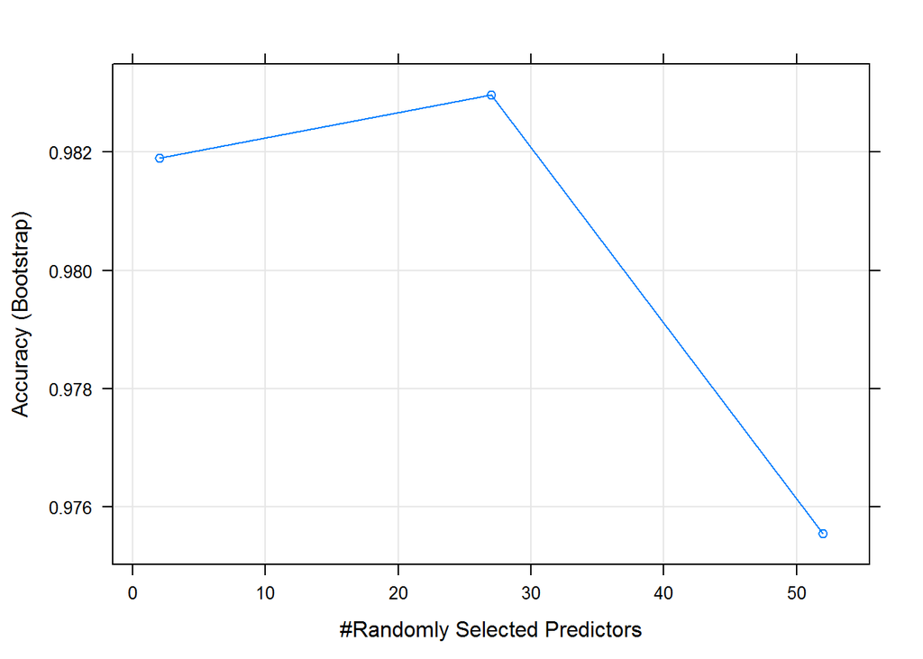

```r
par(mfrow = c(2,2))
plot(RFfit)
```

## Conclusion

Hence by cleaning the data and using all the necessary predictors we are able to build an accurate model. This model can now be used to predict the activity based on the parameters available.